# Meta-analysis-Bd-hypotheses

# Setup & Data

## **Packages**

```r
library(tidyverse)
library(dmetar)
library(meta)
library(metafor)
```

## **Data Read-in**

```r
## FILTER OUT 0-0s!
MetaBdData = read_tsv("Meta_Bd_Data.txt") %>%
  filter(Inclusion=="Yes")

MetaBdData_Lineage = MetaBdData %>%
  filter(Genotype.Analysis=="Y")%>%
  rename(mortality.endemic= mortality.local.or.endemic.Bd, Nendemic = n.local.or.endemic.Bd,Npandemic = n.nonlocal.or.pandemic.Bd, mortality.pandemic=mortality.nonlocal.or.pandemic.Bd)

MetaBdData_Location = MetaBdData %>%
  filter(Location.Analysis=="Y")%>%
  rename(mortality.localBd= mortality.local.or.endemic.Bd, nlocalBd = n.local.or.endemic.Bd,nnonlocalBd = n.nonlocal.or.pandemic.Bd, mortality.nonlocalBd=mortality.nonlocal.or.pandemic.Bd)
```

# **Lineage Hypothesis**

## Main effect model

```r
## using event rate data

## we need number of individuals data...recalculating percantages to numbers
MetaBdData_Lineage2 = MetaBdData_Lineage  %>%
  mutate(Pandemic.ndead = round((mortality.pandemic-Amount.mortality)/100*Npandemic),
         Endemic.ndead=round((mortality.endemic-Amount.mortality)/100*Nendemic)) %>%
  mutate(Pandemic.nlive = Npandemic-Pandemic.ndead,
         Endemic.nlive = Nendemic-Endemic.ndead) %>%
  mutate(Endemic.ndead.cor = if_else(Endemic.ndead < 0, 0, Endemic.ndead))

## calculating the risk ratios from the raw # individuals data
Lineage_RR_data = metafor::escalc(measure="RR", ai=Pandemic.ndead, bi=Pandemic.nlive, ci=Endemic.ndead.cor, di=Endemic.nlive, data=MetaBdData_Lineage2)
## yi = log RR

## main model with a random term for study
Lineage_basemod = rma.mv(yi=yi, V=vi,data = Lineage_RR_data, random = ~1|Shortcitation, slab = Lineage_RR_data$Study.Name,method = "REML")

## model results
summary(Lineage_basemod)
```

```
##
## Multivariate Meta-Analysis Model (k = 18; method: REML)
##
##   logLik  Deviance       AIC       BIC      AICc
## -22.9549   45.9099   49.9099   51.5763   50.7670
##
## Variance Components:
##
##             estim    sqrt  nlvls  fixed         factor
## sigma^2    0.5018  0.7084     10     no  Shortcitation
##
## Test for Heterogeneity:
## Q(df = 17) = 55.2080, p-val < .0001
##
## Model Results:
##
## estimate      se    zval    pval   ci.lb   ci.ub
##   0.8288  0.2510  3.3028  0.0010  0.3370  1.3207  ***
##
## ---
## Signif. codes:  0 '***' 0.001 '**' 0.01 '*' 0.05 '.' 0.1 ' ' 1
```

**Overall all risk ratio**

*estimate in model output is log RR*

```r
## converting log estimate to RR
exp(coef(Lineage_basemod)[[1]])
```

```
## [1] 2.290676
```

```r
## https://www.metafor-project.org/doku.php/tips:meta_regression_with_log_rr
```

## Heterogeneity: I^2

```r
# from metafor package site
W <- diag(1/Lineage_RR_data$vi)
X <- model.matrix(Lineage_basemod)
P <- W - W %*% X %*% solve(t(X) %*% W %*% X) %*% t(X) %*% W
100 * sum(Lineage_basemod$sigma2) / (sum(Lineage_basemod$sigma2) + (Lineage_basemod$k-Lineage_basemod$p)/sum(diag(P)))
```

```
## [1] 78.60231
```

## Plots

*still need to figure out best code for this…*

*not sure about error bars here yet…*

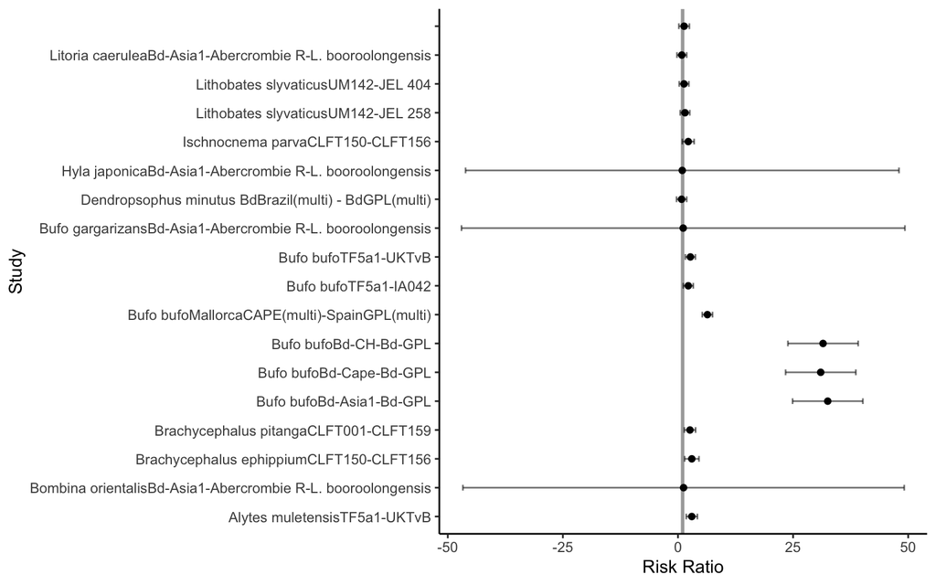

```r
 Lineage_RR_data %>%
  ggplot(aes(x= Study.Name, y = exp(yi))) +
  geom_hline(yintercept=1, size = 1, color = "black", alpha = 0.4) +
  geom_point(aes()) +
  geom_errorbar(aes(ymin = exp(yi)-exp(vi), ymax = exp(yi)+exp(vi), alpha = 0.5), width = 0.2,show.legend = FALSE) + ## not sure about using vi here...???
  theme_classic()+
  scale_x_discrete()+
  xlab("Study")+
  ylab("Risk Ratio") +
  coord_flip()
```

## Detecting Outliers

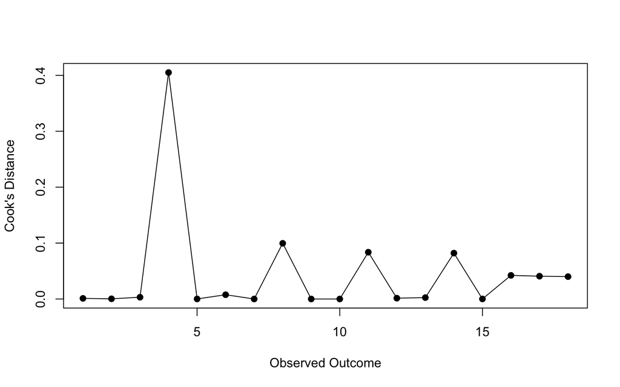

```r
#influential > 0.45
Lineage_CD = cooks.distance.rma.mv(Lineage_basemod)

plot(Lineage_CD, type="o", pch=19, xlab="Observed Outcome", ylab="Cook's Distance")
```

```r
#influential = >1
Lineage_dfB = dfbetas.rma.mv(Lineage_basemod)

Lineage_dfB
```

```
##                                                                                                                    intrcpt
## Lithobates slyvaticusUM142-JEL 404                                                                           -3.383689e-02
## Lithobates slyvaticusUM142-JEL 258                                                                            1.797987e-02
## Alytes muletensisTF5a1-UKTvB                                                                                  5.281630e-02
## Bufo bufoMallorcaCAPE(multi)-SpainGPL(multi)                                                                  7.613421e-01
## Bufo bufoTF5a1-UKTvB                                                                                          7.901139e-03
## Bufo bufoTF5a1-IA042                                                                                         -7.987825e-02
## Bombina orientalisBd-Asia1-Abercrombie R-L. booroolongensis                                                   7.272125e-04
## Litoria caeruleaBd-Asia1-Abercrombie R-L. booroolongensis                                                    -3.536933e-01
## Hyla japonicaBd-Asia1-Abercrombie R-L. booroolongensis                                                       -3.627387e-05
## Bufo gargarizansBd-Asia1-Abercrombie R-L. booroolongensis                                                     5.304393e-04
## Dendropsophus minutus BdBrazil(multi) - BdGPL(multi)                                                         -3.012981e-01
## Brachycephalus ephippiumCLFT150-CLFT156                                                                       3.729034e-02
## Ischnocnema parvaCLFT150-CLFT156                                                                              4.808854e-02
## Serra do Japi, SP 2013; Serra da Graciosa, PR 2014-Serra dos Org\x8bos, RJ 2013;Serra da Graciosa, PR 2014 -2.707608e-01
## Brachycephalus pitangaCLFT001-CLFT159                                                                        -8.740240e-03
## Bufo bufoBd-Asia1-Bd-GPL                                                                                      2.270969e-01
## Bufo bufoBd-CH-Bd-GPL                                                                                         2.226395e-01
## Bufo bufoBd-Cape-Bd-GPL                                                                                       2.203504e-01
```

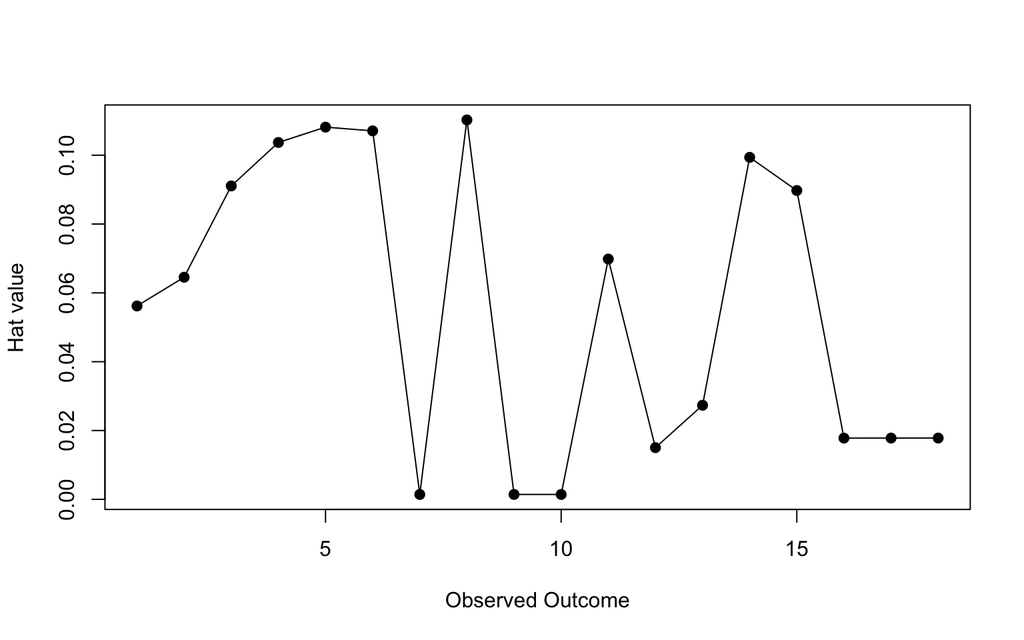

```r
# Hat value outliers < 3*(1/k) == 3*(1/18) == 0.167
Lineage_Hat = hatvalues.rma.mv(Lineage_basemod)

plot(Lineage_Hat, type="o", pch=19, xlab="Observed Outcome", ylab="Hat value")
```

**Outliers:** None

## SubGroup/Moderator models

Useful for interpretation: https://www.metafor-project.org/doku.php/tips:meta_regression_with_log_rr

### Multi-factor model

```r
Lineage_RR_data_noOL = Lineage_RR_data %>%
  filter(!Study.Name== "Bufo bufoMallorcaCAPE(multi)-SpainGPL(multi)")

Lineage_basemod_noOL_Full = rma.mv(yi=yi, V=vi,data = Lineage_RR_data, random = ~1|Shortcitation, mods = ~ host.adult.ecology  + life.stage.exp + Historical.coexistence,slab = Lineage_RR_data$Study.Name, method = "REML")

## model results
summary(Lineage_basemod_noOL_Full)
```

```
##
## Multivariate Meta-Analysis Model (k = 18; method: REML)
##
##   logLik  Deviance       AIC       BIC      AICc
## -10.2351   20.4702   36.4702   39.6533  108.4702
##
## Variance Components:
##
##             estim    sqrt  nlvls  fixed         factor
## sigma^2    0.2171  0.4660     10     no  Shortcitation
##
## Test for Residual Heterogeneity:
## QE(df = 11) = 20.3898, p-val = 0.0403
##
## Test of Moderators (coefficients 2:7):
## QM(df = 6) = 19.1572, p-val = 0.0039
##
## Model Results:
##
##                                                           estimate      se
## intrcpt                                                     0.2892  0.5707
## host.adult.ecologyarboreal                                 -0.4427  0.6934
## host.adult.ecologyterrestrial                               0.6916  0.8062
## life.stage.expexposed as larvae, allowed to metamorphose    0.2005  0.7693
## life.stage.explarvae                                       -0.0353  0.6855
## life.stage.expmetamorph                                     2.4747  1.1370
## Historical.coexistenceYes                                  -0.0826  0.6109
##                                                              zval    pval
## intrcpt                                                    0.5067  0.6124
## host.adult.ecologyarboreal                                -0.6384  0.5232
## host.adult.ecologyterrestrial                              0.8578  0.3910
## life.stage.expexposed as larvae, allowed to metamorphose   0.2606  0.7944
## life.stage.explarvae                                      -0.0514  0.9590
## life.stage.expmetamorph                                    2.1765  0.0295
## Historical.coexistenceYes                                 -0.1353  0.8924
##                                                             ci.lb   ci.ub
## intrcpt                                                   -0.8294  1.4078
## host.adult.ecologyarboreal                                -1.8016  0.9163
## host.adult.ecologyterrestrial                             -0.8886  2.2717
## life.stage.expexposed as larvae, allowed to metamorphose  -1.3073  1.7083
## life.stage.explarvae                                      -1.3787  1.3082
## life.stage.expmetamorph                                    0.2462  4.7031  *
## Historical.coexistenceYes                                 -1.2799  1.1146
##
## ---
## Signif. codes:  0 '***' 0.001 '**' 0.01 '*' 0.05 '.' 0.1 ' ' 1
```

**model comparison**

```r
Lineage_basemodML = rma.mv(yi=yi, V=vi,data = Lineage_RR_data, random = ~1|Shortcitation,slab = Lineage_RR_data$Study.Name, method = "ML")

Lineage_basemod_FullML = rma.mv(yi=yi, V=vi,data = Lineage_RR_data, random = ~1|Shortcitation, mods = ~ host.adult.ecology  + life.stage.exp + Historical.coexistence,slab = Lineage_RR_data$Study.Name, method = "ML")

## says REML is not meaningful?  Switched to ML
anova(Lineage_basemodML,Lineage_basemod_FullML)
```

```
##
##         df     AIC     BIC    AICc   logLik     LRT   pval      QE
## Full     8 43.9492 51.0722 59.9492 -13.9746                20.3898
## Reduced  2 51.7954 53.5762 52.5954 -23.8977 19.8462 0.0029 55.2080
```

**Conclusion** Full model is “better” than intercept only model *random study term included in both*

### Single factor models

**Host Ecology**

```r
Lineage_basemod_noOL_HEco = rma.mv(yi=yi, V=vi,data = Lineage_RR_data, random = ~1|Shortcitation, mods = ~ host.adult.ecology, slab = Lineage_RR_data$Study.Name, method = "REML")

## model results
summary(Lineage_basemod_noOL_HEco)
```

```
##
## Multivariate Meta-Analysis Model (k = 18; method: REML)
##
##   logLik  Deviance       AIC       BIC      AICc
## -16.4897   32.9794   40.9794   43.8116   44.9794
##
## Variance Components:
##
##             estim    sqrt  nlvls  fixed         factor
## sigma^2    0.2298  0.4794     10     no  Shortcitation
##
## Test for Residual Heterogeneity:
## QE(df = 15) = 32.5424, p-val = 0.0054
##
## Test of Moderators (coefficients 2:3):
## QM(df = 2) = 12.1715, p-val = 0.0023
##
## Model Results:
##
##                                estimate      se     zval    pval    ci.lb
## intrcpt                          0.2838  0.5759   0.4928  0.6221  -0.8450
## host.adult.ecologyarboreal      -0.4177  0.6561  -0.6366  0.5244  -1.7036
## host.adult.ecologyterrestrial    0.7937  0.6112   1.2986  0.1941  -0.4042
##                                 ci.ub
## intrcpt                        1.4127
## host.adult.ecologyarboreal     0.8682
## host.adult.ecologyterrestrial  1.9916
##
## ---
## Signif. codes:  0 '***' 0.001 '**' 0.01 '*' 0.05 '.' 0.1 ' ' 1
```

**Life Stage**

Conclusion: Significant, metamorph category

```r
Lineage_basemod_noOL_LS = rma.mv(yi=yi, V=vi,data = Lineage_RR_data, random = ~1|Shortcitation, mods = ~ + life.stage.exp,slab = Lineage_RR_data$Study.Name, method = "REML")

## model results
summary(Lineage_basemod_noOL_LS)
```

```
##
## Multivariate Meta-Analysis Model (k = 18; method: REML)
##
##   logLik  Deviance       AIC       BIC      AICc
## -15.2430   30.4861   40.4861   43.6814   47.9861
##
## Variance Components:
##
##             estim    sqrt  nlvls  fixed         factor
## sigma^2    0.2180  0.4669     10     no  Shortcitation
##
## Test for Residual Heterogeneity:
## QE(df = 14) = 31.0388, p-val = 0.0055
##
## Test of Moderators (coefficients 2:4):
## QM(df = 3) = 12.1560, p-val = 0.0069
##
## Model Results:
##
##                                                           estimate      se
## intrcpt                                                     0.2500  0.2816
## life.stage.expexposed as larvae, allowed to metamorphose    0.8486  0.6979
## life.stage.explarvae                                        0.6956  0.3887
## life.stage.expmetamorph                                     3.2054  0.9872
##                                                             zval    pval
## intrcpt                                                   0.8879  0.3746
## life.stage.expexposed as larvae, allowed to metamorphose  1.2160  0.2240
## life.stage.explarvae                                      1.7897  0.0735
## life.stage.expmetamorph                                   3.2469  0.0012
##                                                             ci.lb   ci.ub
## intrcpt                                                   -0.3019  0.8019
## life.stage.expexposed as larvae, allowed to metamorphose  -0.5192  2.2163
## life.stage.explarvae                                      -0.0662  1.4574   .
## life.stage.expmetamorph                                    1.2705  5.1403  **
##
## ---
## Signif. codes:  0 '***' 0.001 '**' 0.01 '*' 0.05 '.' 0.1 ' ' 1
```

**Color-coded plot**

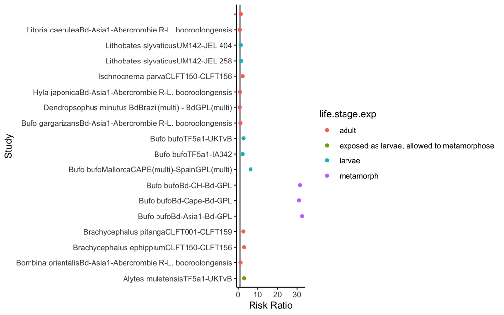

```r
 Lineage_RR_data %>%
  ggplot(aes(x= Study.Name, y = exp(yi))) +
  geom_hline(yintercept=1, size = 1, color = "black", alpha = 0.4) +
  geom_point(aes(color=life.stage.exp)) +
  #geom_errorbar(aes(ymin = exp(yi)-exp(vi), ymax = exp(yi)+exp(vi), alpha = 0.5), width = 0.2,show.legend = FALSE) + ## not sure about using vi here...???
  theme_classic()+
  scale_x_discrete()+
  xlab("Study")+
  ylab("Risk Ratio") +
  coord_flip()
```

**Historical Coexistence**

```r
Lineage_basemod_noOL_HisCo = rma.mv(yi=yi, V=vi,data = Lineage_RR_data, random = ~1|Shortcitation, mods = ~ Historical.coexistence,slab = Lineage_RR_data$Study.Name, method = "REML")

## model results
summary(Lineage_basemod_noOL_HisCo)
```

```
##
## Multivariate Meta-Analysis Model (k = 18; method: REML)
##
##   logLik  Deviance       AIC       BIC      AICc
## -21.9366   43.8733   49.8733   52.1911   51.8733
##
## Variance Components:
##
##             estim    sqrt  nlvls  fixed         factor
## sigma^2    0.5822  0.7630     10     no  Shortcitation
##
## Test for Residual Heterogeneity:
## QE(df = 16) = 55.1740, p-val < .0001
##
## Test of Moderators (coefficient 2):
## QM(df = 1) = 0.0423, p-val = 0.8370
##
## Model Results:
##
##                            estimate      se     zval    pval    ci.lb   ci.ub
## intrcpt                      0.8729  0.3096   2.8195  0.0048   0.2661  1.4796
## Historical.coexistenceYes   -0.1080  0.5249  -0.2057  0.8370  -1.1367  0.9208
##
## intrcpt                    **
## Historical.coexistenceYes
##
## ---
## Signif. codes:  0 '***' 0.001 '**' 0.01 '*' 0.05 '.' 0.1 ' ' 1
```

**Color-coded plot**

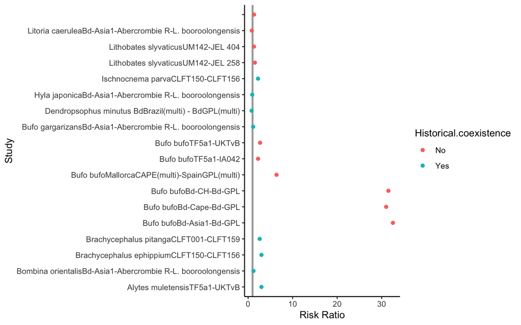

```r
 Lineage_RR_data %>%
  ggplot(aes(x= Study.Name, y = exp(yi))) +
  geom_hline(yintercept=1, size = 1, color = "black", alpha = 0.4) +
  geom_point(aes(color=Historical.coexistence)) +
  #geom_errorbar(aes(ymin = exp(yi)-exp(vi), ymax = exp(yi)+exp(vi), alpha = 0.5), width = 0.2,show.legend = FALSE) + ## not sure about using vi here...???
  theme_classic()+
  scale_x_discrete()+
  xlab("Study")+
  ylab("Risk Ratio") +
  coord_flip()
```

# **Location Hypothesis**

## Main model

```r
## using event rate data

## we need number of individuals data...recalculating percantages to numbers
MetaBdData_Location2 = MetaBdData_Location %>%
  mutate(nonLocal.ndead = round((mortality.nonlocalBd-Amount.mortality)/100*nnonlocalBd),
         Local.ndead=round((mortality.localBd-Amount.mortality)/100*nlocalBd)) %>%
  mutate(nonLocal.nlive = nnonlocalBd-nonLocal.ndead,Local.nlive = nlocalBd-Local.ndead) %>%
  mutate(Local.ndead.cor = if_else(Local.ndead < 0, 0, Local.ndead)) %>%
  mutate(nonLocal.ndead.cor = if_else(nonLocal.ndead < 0, 0, nonLocal.ndead))

## calculating the risk ratios from the raw # individuals data
Location_RR_data = metafor::escalc(measure="RR", ai=nonLocal.ndead.cor, bi=nonLocal.nlive, ci=Local.ndead.cor, di=Local.nlive, data=MetaBdData_Location2)

## main model with a random term for study
Location_basemod = rma.mv(yi=yi, V=vi,data = Location_RR_data, random = ~1|Shortcitation, slab = Location_RR_data$Study.Name)

## model results
summary(Location_basemod)
```

```
##
## Multivariate Meta-Analysis Model (k = 23; method: REML)
##
##   logLik  Deviance       AIC       BIC      AICc
## -34.9533   69.9066   73.9066   76.0887   74.5382
##
## Variance Components:
##
##             estim    sqrt  nlvls  fixed         factor
## sigma^2    0.3934  0.6272      8     no  Shortcitation
##
## Test for Heterogeneity:
## Q(df = 22) = 60.5371, p-val < .0001
##
## Model Results:
##
## estimate      se     zval    pval    ci.lb   ci.ub
##  -0.0133  0.2557  -0.0519  0.9586  -0.5144  0.4879
##
## ---
## Signif. codes:  0 '***' 0.001 '**' 0.01 '*' 0.05 '.' 0.1 ' ' 1
```

## Heterogeneity: I^2

```r
# from metafor package site
W <- diag(1/Location_RR_data$vi)
X <- model.matrix(Location_basemod)
P <- W - W %*% X %*% solve(t(X) %*% W %*% X) %*% t(X) %*% W
100 * sum(Location_basemod$sigma2) / (sum(Location_basemod$sigma2) + (Location_basemod$k-Location_basemod$p)/sum(diag(P)))
```

```
## [1] 70.42453
```

## Plots

*still need to figure out best code for this…*

*not sure about error bars here…*

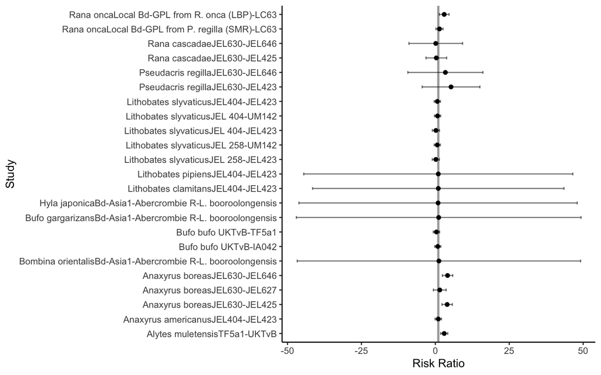

```r
Location_RR_data %>%
  ggplot(aes(x= Study.Name, y = exp(yi))) +
  geom_hline(yintercept=1, size = 1, color = "black", alpha = 0.4) +
  geom_point(aes()) +
  geom_errorbar(aes(ymin = exp(yi)-exp(vi), ymax = exp(yi)+exp(vi), alpha = 0.5), width = 0.2,show.legend = FALSE) + ## not sure about using vi here...???
  theme_classic()+
  scale_x_discrete()+
  xlab("Study")+
  ylab("Risk Ratio") +
  coord_flip()
```

**Conclusion**: model not significant, no overarching effect in a given direction

## Outliers

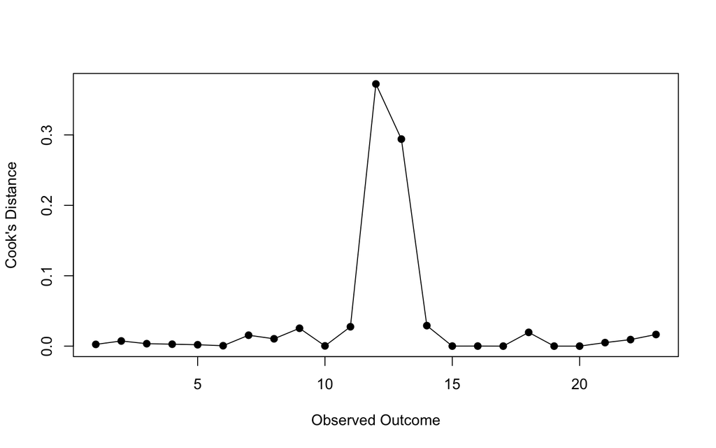

```r
Location_CD = cooks.distance.rma.mv(Location_basemod)

plot(Location_CD, type="o", pch=19, xlab="Observed Outcome", ylab="Cook's Distance")
```

```r
Location_CD %>% as.data.frame()
```

```
##                                                                        .
## Lithobates slyvaticusJEL 404-JEL423                         2.482023e-03
## Lithobates slyvaticusJEL 404-UM142                          7.317769e-03
## Lithobates slyvaticusJEL 258-JEL423                         3.471272e-03
## Lithobates slyvaticusJEL 258-UM142                          2.744416e-03
## Pseudacris regillaJEL630-JEL423                             1.956403e-03
## Pseudacris regillaJEL630-JEL646                             5.726521e-04
## Rana cascadaeJEL630-JEL425                                  1.549083e-02
## Rana cascadaeJEL630-JEL646                                  1.040132e-02
## Anaxyrus boreasJEL630-JEL425                                2.537732e-02
## Anaxyrus boreasJEL630-JEL627                                3.129902e-04
## Anaxyrus boreasJEL630-JEL646                                2.751859e-02
## Alytes muletensisTF5a1-UKTvB                                3.723948e-01
## Bufo bufo UKTvB-TF5a1                                       2.940833e-01
## Bufo bufo UKTvB-IA042                                       2.910666e-02
## Bombina orientalisBd-Asia1-Abercrombie R-L. booroolongensis 4.844433e-05
## Hyla japonicaBd-Asia1-Abercrombie R-L. booroolongensis      7.344584e-05
## Bufo gargarizansBd-Asia1-Abercrombie R-L. booroolongensis   8.949868e-06
## Lithobates slyvaticusJEL404-JEL423                          1.954302e-02
## Lithobates clamitansJEL404-JEL423                           1.048969e-06
## Lithobates pipiensJEL404-JEL423                             1.011529e-06
## Anaxyrus americanusJEL404-JEL423                            4.988171e-03
## Rana oncaLocal Bd-GPL from P. regilla (SMR)-LC63            9.271756e-03
## Rana oncaLocal Bd-GPL from R. onca (LBP)-LC63               1.652908e-02
```

```r
#influential = >1
Location_dfB = dfbetas.rma.mv(Location_basemod)

Location_dfB
```

```
##                                                                  intrcpt
## Lithobates slyvaticusJEL 404-JEL423                         -0.050999350
## Lithobates slyvaticusJEL 404-UM142                           0.081440661
## Lithobates slyvaticusJEL 258-JEL423                         -0.060553412
## Lithobates slyvaticusJEL 258-UM142                           0.050793672
## Pseudacris regillaJEL630-JEL423                              0.044932121
## Pseudacris regillaJEL630-JEL646                              0.024128277
## Rana cascadaeJEL630-JEL425                                  -0.118213338
## Rana cascadaeJEL630-JEL646                                  -0.097839745
## Anaxyrus boreasJEL630-JEL425                                 0.167725864
## Anaxyrus boreasJEL630-JEL627                                -0.017515841
## Anaxyrus boreasJEL630-JEL646                                 0.175021934
## Alytes muletensisTF5a1-UKTvB                                 0.711745514
## Bufo bufo UKTvB-TF5a1                                       -0.605523585
## Bufo bufo UKTvB-IA042                                       -0.155334425
## Bombina orientalisBd-Asia1-Abercrombie R-L. booroolongensis  0.006913689
## Hyla japonicaBd-Asia1-Abercrombie R-L. booroolongensis      -0.008505187
## Bufo gargarizansBd-Asia1-Abercrombie R-L. booroolongensis    0.002971103
## Lithobates slyvaticusJEL404-JEL423                          -0.139595472
## Lithobates clamitansJEL404-JEL423                            0.001023999
## Lithobates pipiensJEL404-JEL423                              0.001005562
## Anaxyrus americanusJEL404-JEL423                             0.069496979
## Rana oncaLocal Bd-GPL from P. regilla (SMR)-LC63            -0.091053385
## Rana oncaLocal Bd-GPL from R. onca (LBP)-LC63                0.132666573
```

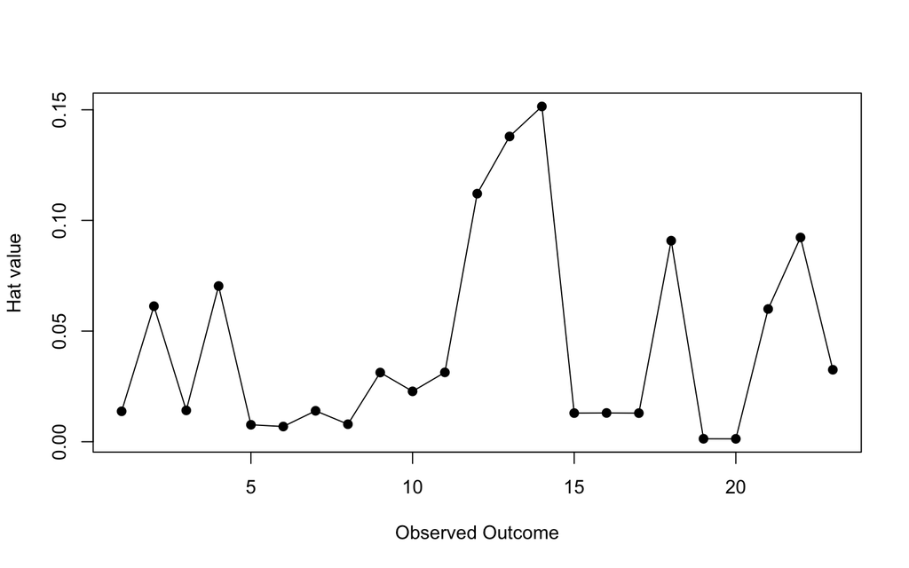

```r
# Hat value outliers < 3*(1/k) == 3*(1/30) == 0.1
Location_Hat = hatvalues.rma.mv(Location_basemod)

plot(Location_Hat, type="o", pch=19, xlab="Observed Outcome", ylab="Hat value")
```

## SubGroup/Moderator models

Useful for interpretation: https://www.metafor-project.org/doku.php/tips:meta_regression_with_log_rr

**multi-factor model**

```r
Location_RR_data_noOL = Location_RR_data %>%
  filter(!Study.Name== "Alytes muletensisTF5a1-UKTvB") %>%
  filter(!Study.Name== "Anaxyrus americanusJEL404-JEL423") %>%
  filter(!Study.Name== "Bufo bufo UKTvB-IA042")

Location_basemod_Full = rma.mv(yi=yi, V=vi,data = Location_RR_data_noOL, random = ~1|Shortcitation, mods = ~ host.adult.ecology + life.stage.exp,slab = Location_RR_data_noOL$Study.Name, method = "REML")

## model results
summary(Location_basemod_Full)
```

```
##
## Multivariate Meta-Analysis Model (k = 20; method: REML)
##
##   logLik  Deviance       AIC       BIC      AICc
## -23.9762   47.9524   61.9524   66.4258   80.6191
##
## Variance Components:
##
##             estim    sqrt  nlvls  fixed         factor
## sigma^2    0.8953  0.9462      6     no  Shortcitation
##
## Test for Residual Heterogeneity:
## QE(df = 14) = 38.0617, p-val = 0.0005
##
## Test of Moderators (coefficients 2:6):
## QM(df = 5) = 3.7292, p-val = 0.5890
##
## Model Results:
##
##                                 estimate      se     zval    pval    ci.lb
## intrcpt                           0.1942  2.1829   0.0889  0.9291  -4.0842
## host.adult.ecologyarboreal        0.1404  2.4677   0.0569  0.9546  -4.6962
## host.adult.ecologysemi-aquatic   -1.4892  2.5502  -0.5840  0.5592  -6.4874
## host.adult.ecologyterrestrial    -0.4800  2.4684  -0.1945  0.8458  -5.3180
## life.stage.explarvae              0.2797  1.8150   0.1541  0.8775  -3.2777
## life.stage.expmetamorph           1.3617  1.9583   0.6953  0.4868  -2.4765
##                                  ci.ub
## intrcpt                         4.4725
## host.adult.ecologyarboreal      4.9770
## host.adult.ecologysemi-aquatic  3.5090
## host.adult.ecologyterrestrial   4.3579
## life.stage.explarvae            3.8371
## life.stage.expmetamorph         5.1999
##
## ---
## Signif. codes:  0 '***' 0.001 '**' 0.01 '*' 0.05 '.' 0.1 ' ' 1
```

**model comparison**

```r
Location_basemodML = rma.mv(yi=yi, V=vi,data = Location_RR_data_noOL, random = ~1|Shortcitation,slab = Location_RR_data_noOL$Study.Name, method = "ML")

Location_basemod_FullML = rma.mv(yi=yi, V=vi,data = Location_RR_data_noOL, random = ~1|Shortcitation, mods = ~ host.adult.ecology  + life.stage.exp,slab = Location_RR_data_noOL$Study.Name, method = "ML")

## says REML is not meaningful?  Switched to ML
anova(Location_basemodML,Location_basemod_FullML)
```

```
##
##         df     AIC     BIC    AICc   logLik    LRT   pval      QE
## Full     7 77.8601 84.8302 87.1934 -31.9300               38.0617
## Reduced  2 70.5719 72.5634 71.2778 -33.2860 2.7119 0.7443 47.0736
```

**Conclusion** Full model is “NOT better” than intercept only model *random study term included in both*

**single factor models**

**Host Ecology**

Conclusion: Not Significant

```r
Location_basemod_noOL_HEco = rma.mv(yi=yi, V=vi,data = Location_RR_data_noOL, random = ~1|Shortcitation, mods = ~ host.adult.ecology, slab = Location_RR_data_noOL$Study.Name, method = "REML")

## model results
summary(Location_basemod_noOL_HEco)
```

```
##
## Multivariate Meta-Analysis Model (k = 20; method: REML)
##
##   logLik  Deviance       AIC       BIC      AICc
## -27.5732   55.1465   65.1465   69.0094   71.1465
##
## Variance Components:
##
##             estim    sqrt  nlvls  fixed         factor
## sigma^2    0.6506  0.8066      6     no  Shortcitation
##
## Test for Residual Heterogeneity:
## QE(df = 16) = 39.4347, p-val = 0.0009
##
## Test of Moderators (coefficients 2:4):
## QM(df = 3) = 1.2225, p-val = 0.7476
##
## Model Results:
##
##                                 estimate      se     zval    pval    ci.lb
## intrcpt                           0.2523  2.0927   0.1206  0.9040  -3.8492
## host.adult.ecologyarboreal        0.3474  2.2725   0.1529  0.8785  -4.1067
## host.adult.ecologysemi-aquatic   -0.8332  2.1731  -0.3834  0.7014  -5.0923
## host.adult.ecologyterrestrial    -0.3419  2.1157  -0.1616  0.8716  -4.4887
##                                  ci.ub
## intrcpt                         4.3538
## host.adult.ecologyarboreal      4.8014
## host.adult.ecologysemi-aquatic  3.4260
## host.adult.ecologyterrestrial   3.8048
##
## ---
## Signif. codes:  0 '***' 0.001 '**' 0.01 '*' 0.05 '.' 0.1 ' ' 1
```

**Life Stage**

Conclusion: Not Significant

```r
Location_basemod_noOL_LS = rma.mv(yi=yi, V=vi,data = Location_RR_data_noOL, random = ~1|Shortcitation, mods = ~ + life.stage.exp,slab = Location_RR_data_noOL$Study.Name, method = "REML")

## model results
summary(Location_basemod_noOL_LS)
```

```
##
## Multivariate Meta-Analysis Model (k = 20; method: REML)
##
##   logLik  Deviance       AIC       BIC      AICc
## -28.7764   57.5528   65.5528   68.8857   68.8862
##
## Variance Components:
##
##             estim    sqrt  nlvls  fixed         factor
## sigma^2    0.3543  0.5952      6     no  Shortcitation
##
## Test for Residual Heterogeneity:
## QE(df = 17) = 42.4945, p-val = 0.0006
##
## Test of Moderators (coefficients 2:3):
## QM(df = 2) = 1.4276, p-val = 0.4898
##
## Model Results:
##
##                          estimate      se     zval    pval    ci.lb   ci.ub
## intrcpt                    0.0815  1.2817   0.0636  0.9493  -2.4306  2.5935
## life.stage.explarvae      -0.3182  1.3156  -0.2419  0.8089  -2.8968  2.2603
## life.stage.expmetamorph    0.4930  1.4684   0.3357  0.7371  -2.3851  3.3710
##
## ---
## Signif. codes:  0 '***' 0.001 '**' 0.01 '*' 0.05 '.' 0.1 ' ' 1
```